# Gaindrifts_04022019

```python
import pylab as pl
from  numpy.random import normal
import numpy as np
import healpy as hp
from scipy  import  signal
from scipy.signal import periodogram

from pylab import cm
cmap = cm.get_cmap('RdYlBu')
cmap.set_under('w')
from __future__ import print_function
from ipywidgets import interact, interactive, fixed, interact_manual
import ipywidgets as widgets
```

```python
from IPython.display import HTML

HTML('''<script>
code_show=true;
function code_toggle() {
 if (code_show){
 $('div.input').hide();
 } else {
 $('div.input').show();
 }
 code_show = !code_show
}
$( document ).ready(code_toggle);
</script>
<form action="javascript:code_toggle()"><input type="submit" value="Click here to toggle on/off the raw code."></form>''')
```

## Injecting Gain Drifts

We inject drifts with a $1/f$ dependence with $f_{knee}=150 $ mHz (see PSD below) on all detectors within a detector pair .

The input signal encodes: Monopole + Dipole + CMB T fluctuations. So far, no noise is injected to data.

We estimated maps with MADAM destriper (baseline=60 sec)

## Mitigating leakage

To mitigate the leakage we estimate the gain by regressing the signal against a template encoding the **CMB T** with $\ell \gtrsim 50$.

Below are the mitigation steps to a generic TOD $d_t$:

$^{(1)}$ Given an $\ell_c$ (to retain only signal @ $\ell> \ell_c$ ) we estimate $ f_c$ as : $$ \ell_c = 2 \pi f_c/ \omega_{scan} $$ $\omega_{scan} $ is the scanning speed and it 's defined as : $$ \omega_{scan} = \sin (\beta ) * spinrate = 0.0013 rad/sec =0.07 deg/sec$$ Where $\beta$ is the angle between the boresight and the spin axis (50 deg according to latest values) , and the spin rate is 0.1 rpm .

thus, if $\ell_c=50$ , $f_c= 10$ mHz

### Gain Drift signal

```python
fs = 20.  ; fknee=0.15; fcutoff=0.01
```

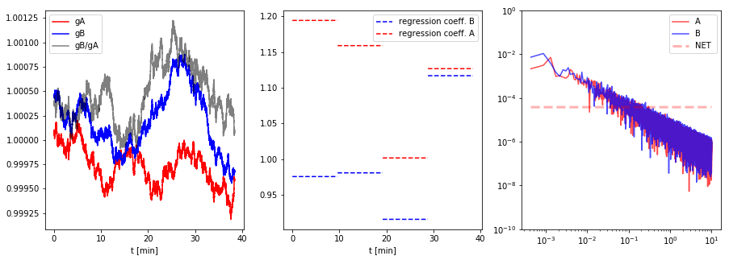

```python
g  = pl.load('/Users/peppe/work/satellite_sims/drifting_gain/gains.npy')
ge = pl.load('/Users/peppe/work/satellite_sims/drifting_gain/gains_newproc.npy')
N= pl.int32 (20*60*9.6)
T0 = 9.6
t= pl.linspace (0,9.6, N)
fig = pl.figure(figsize=(15,5))
for i in range(4):
    #print ((t +i*T0).shape , g[0,i*N:(i+1)*N].shape)
    if i ==0:
        ax1 = fig.add_subplot(131);

        ax1.plot(t +i*T0 ,1 + g[0][i*N:(i+1)*N], 'r', label='gA')
        ax1.plot(t +i*T0 , 1 + g[1][i*N:(i+1)*N], 'b', label='gB')



        ax1.plot(t +i*T0 ,  ( 1 + g[1][i*N:(i+1)*N] ) /(1 + g[0][i*N:(i+1)*N]), 'k',  label='gB/gA' ,alpha=.5)

        ax2 = fig.add_subplot  (132)
        ax2.plot(t +i*T0 ,pl.ones(N)* ge[i][1],'b--' , label='regression coeff. B')
        ax2.plot(t +i*T0 , pl.ones(N)*ge[i][0],'r--', label='regression coeff. A'  )
    else :
        ax1 = fig.add_subplot(131);

        ax1.plot(t +i*T0 ,1 + g[0][i*N:(i+1)*N], 'r' )
        ax1.plot(t +i*T0 , 1 + g[1][i*N:(i+1)*N], 'b' )



        ax1.plot(t +i*T0 ,  ( 1 + g[1][i*N:(i+1)*N] ) /(1 + g[0][i*N:(i+1)*N]), 'k'  ,alpha=.5)

        ax2 = fig.add_subplot  (132)
        ax2.plot(t +i*T0 ,pl.ones(N)* ge[i][1],'b--'  )
        ax2.plot(t +i*T0 , pl.ones(N)*ge[i][0],'r--'   )
ax1.legend()
ax1.set_xlabel('t [min]')
ax2.set_xlabel('t [min]')
ax3=fig.add_subplot(133)
freq, specA = signal.periodogram( g[0][:4*N] ,fs=fs, scaling='density')
ax3.loglog(freq, pl.sqrt(specA), 'r',  alpha=.7 , label='A',  )
freq, specB= signal.periodogram(g[1][:4*N]  ,fs=fs, scaling='density')
ax3.loglog(freq, pl.sqrt( specB),  'b', alpha=.7 , label='B'  )
ax3.loglog(freq, pl.ones_like(freq)*3.8e-5,'r--', alpha=.3, linewidth=3, label='NET ' )
ax3.set_ylim([1e-10,1])

ax2.legend()
ax3.legend()

pl.show()
```

**Fig1** (left) Comparison of 40 min gain drift signal for both det A and det B respectively in red and blue. their ratio is shown in grey. (middle) Gain estimates from regression coefficient performed on 10 min chunks of data. (right) PSD of the signals in left panel following the same color scheme. Notice that the drift shows a 1/f dependence as expected.

### Detector PSD

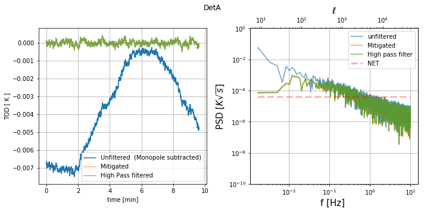

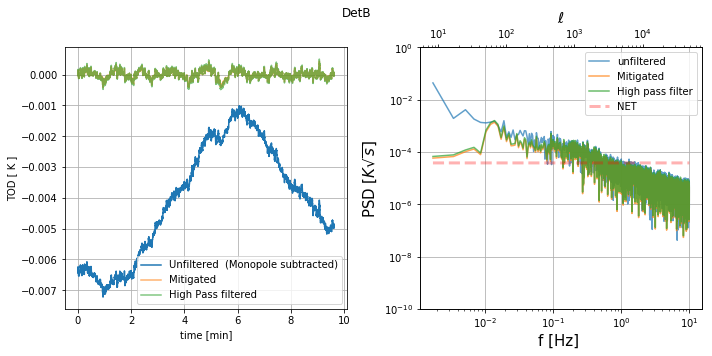

```python
def showTOD(det):

    dicx = {0 :'A', 1:'B',  }
    cmbt=   pl.load('/Users/peppe/work/satellite_sims/drifting_gain/sigonly_tod_wodrifts.npy') [0]
    drift=   pl.load('/Users/peppe/work/satellite_sims/drifting_gain/drifttod.npy') [0]
    mit=   pl.load('/Users/peppe/work/satellite_sims/drifting_gain/mittod.npy') [0]
    filt=   pl.load('/Users/peppe/work/satellite_sims/drifting_gain/filttod.npy') [0]

    N=len(mit[1])

    fig =pl.figure(figsize=(10,5))
    ax1 = fig.add_subplot(122);
    ax2 = ax1.twiny() ;

    ax2.set_xlabel(r'$\ell$', fontsize=15);
    ax1.set_xlabel('f [Hz] ', fontsize=15);
    ax1.set_ylabel('PSD ['+r'$K \sqrt{s}$]', fontsize=15)
    #pl.subplot(122)

    pl.suptitle('Det{}'.format(dicx[det]))
    freq, driftspec= signal.periodogram(drift[det]  ,fs=fs, scaling='density')
    ax1.loglog(freq, pl.sqrt(driftspec),  alpha=.7 , label='unfiltered'  )
    freq, mitspec= signal.periodogram(mit[det] ,fs=fs, scaling='density')

    ax1.loglog(freq, pl.sqrt(mitspec),  alpha=.7 , label='Mitigated'   )

    #freq, fspectrum= signal.periodogram(( cmbt[det])[:N] ,fs=fs, scaling='density')
    freq, filtspec= signal.periodogram(filt[det]  ,fs=fs, scaling='density')
    ax1.loglog(freq, pl.sqrt(filtspec),  alpha=.7 , label='High pass filter'  )
    #ax1.loglog(freq, pl.sqrt(fspectrum),     alpha=.5
    #           , color='black' , label='CMB '  )
    ax1.loglog(freq, pl.ones_like(freq)*3.8e-5,'r--', alpha=.3, linewidth=3, label='NET ' )
    ax2.loglog(2.*pl.pi*freq/0.0013, pl.zeros_like(freq) );
    ax1.legend()

    ax1.grid()

    pl.ylim([1e-10,1])

    pl.subplot(121)
    t_array = pl.arange(N)/fs/60.
    pl.plot(t_array ,     drift[det]-2.725, label='Unfiltered  (Monopole subtracted)' )

    pl.plot(t_array ,     mit[det], alpha=.6, label='Mitigated' )
    pl.plot(t_array ,     filt[det], alpha=.6, label='High Pass filtered' )

    pl.grid()
    #pl.ylim([-.01,.01])

    pl.xlabel('time [min]')
    pl.ylabel('TOD [ K ]')
    pl.legend()
    pl.tight_layout()

#w= interact (showTOD, det=[('A', 0), ('B', 1) ])

showTOD(0)
showTOD(1)
```

**Fig2** (top) and (bottom) panels show 10 minutes of time samples and their respective PSD for a pair of detectors. (solid blue) is the signal w/ gaindrifts encoding Monopole (which has been subtracted for graphical purposes ) Dipole and CMB temperature fluctuations, (solid green) is the timestream after the high pass filter and (solid orange) with the regression coefficients applied. As shown in the plots above, these coefficients flutuates around 1, this is the reason why we observe a slight difference between the orange and green lines. Notice that in the PSD as expected all the modes with $\ell < 50$ have been filtered. As a reference we show with a dashed red line the $38 \mu K \sqrt{s}$ NET level for a LB detector.

## Pair sum and pair diff

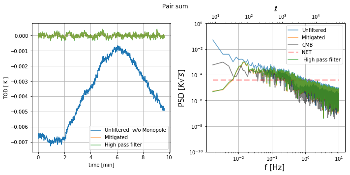

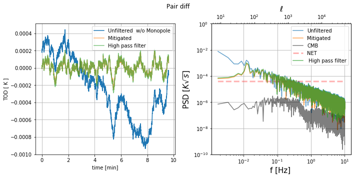

```python
def showperpair(Pair):

    dicx = {  0:'sum',  1:'diff'   }
    cmbt=   pl.load('/Users/peppe/work/satellite_sims/drifting_gain/tod_cmbonly.npy') [0]
    drift=   pl.load('/Users/peppe/work/satellite_sims/drifting_gain/drifttod.npy') [0]
    mit=   pl.load('/Users/peppe/work/satellite_sims/drifting_gain/mittod.npy') [0]
    filt=   pl.load('/Users/peppe/work/satellite_sims/drifting_gain/filttod.npy') [0]
    if  Pair :
        driftdiff= .5*(drift[1] -drift[0])
        cmbtdiff = .5*(cmbt[1] -cmbt[0])
        mitdiff  = .5*(mit[1] -mit[0])
        filtdiff  = .5*(filt[1] -filt[0])

    else:
        driftdiff= .5*(drift[1] +drift[0]) - 2.725
        cmbtdiff = .5*(cmbt[1] +cmbt[0])
        mitdiff  = .5*(mit[1] +mit[0])
        filtdiff  = .5*(filt[1] + filt[0])

    N=len(mit[1])

    fig =pl.figure(figsize=(10,5))
    ax1 = fig.add_subplot(122);
    ax2 = ax1.twiny() ;

    ax2.set_xlabel(r'$\ell$', fontsize=15);
    ax1.set_xlabel('f [Hz] ', fontsize=15);
    ax1.set_ylabel('PSD ['+r'$K \sqrt{s}$]', fontsize=15)
    pl.suptitle('Pair {}'.format(dicx[Pair]))
    freq, driftspec= signal.periodogram(driftdiff  ,fs=fs, scaling='density')
    ax1.loglog(freq, pl.sqrt(driftspec),  alpha=.7, label='Unfiltered'    )
    freq, mitspec= signal.periodogram(mitdiff ,fs=fs, scaling='density')

    ax1.loglog(freq, pl.sqrt(mitspec),  alpha=.7 , label='Mitigated'   )

    freq, fspectrum= signal.periodogram(( cmbtdiff)[:N] ,fs=fs, scaling='density')
    ax1.loglog(freq, pl.sqrt(fspectrum),     alpha=.5
               , color='black'  , label='CMB' )

    ax1.loglog(freq, pl.ones_like(freq)*3.8e-5,'r--', alpha=.3, linewidth=3, label='NET ' )
    ax2.loglog(2.*pl.pi*freq/0.0013, pl.zeros_like(freq) );
    freq, filtspec= signal.periodogram(filtdiff ,fs=fs, scaling='density')
    ax1.loglog(freq, pl.sqrt(filtspec),  alpha=.7 , label=' High pass filter'   )
    ax1.legend()

    ax1.grid()

    pl.ylim([1e-10,1])


    pl.subplot(121)
    t_array = pl.arange(N)/fs/60.
    pl.plot(t_array ,    driftdiff, label='Unfiltered  w/o Monopole' )

    pl.plot(t_array ,     mitdiff, alpha=.6, label='Mitigated' )
    pl.plot(t_array ,     filtdiff, alpha=.6, label='High pass filter' )

    #t_array = pl.arange(len(cmbt[0] ))/fs/60.
    #pl.plot(t_array ,     (cmbtdiff ) [:N], alpha=.3, color='black', label='CMB'  )

    pl.grid()
    #pl.ylim([-.01,.01])

    pl.xlabel('time [min]')
    pl.ylabel('TOD [ K ]')
    pl.legend()
    pl.tight_layout()
#w= interact (showperpair, Pair=[('sum', 0), ('diff', 1) ])

showperpair(0)
showperpair(1)
```

**Fig3** (top) and (bottom) panels show 10 minutes of time samples and their respective PSD respectively for sum and diff of a detector pair. (solid blue) is the signal w/ gaindrifts encoding Monopole ( subtracted for graphical purposes on the top panel ) Dipole and CMB temperature fluctuations, (solid green) is is the timestream after the high pass filter and (solid orange) with the regression coefficient applied. As shown in the plots above, these coefficients flutuates around 1, this is the reason why we observe a slight difference between the orange and green lines. Notice that in the PSD as expected all the modes with $\ell < 50$ have been filtered. As a reference we show w/ a dashed red line the $38 \mu K \sqrt{s}$ NET level for a LB detector.We also show in solid gray the PSD of CMB intensity ( top panel) and CMB Polarization signal (bottom panel).